# F9_04_SCHED_B_REQ_X

Required to complete Schedule B [x] · Checkbox report

## Overview

**Description**

Schedule B required?

**Table**

`F9-P04-T00-REQUIRED-SCHEDULES` (one)

**Location code**

`F990-PC-PART-04-LINE-02`, `F990-EZ-PART-00-SECTION-H`

**Family**

`F990-PC-PART-04-LINE-02`

**Data type**

checkbox (xsd: , CheckboxType, BooleanType)

**Scope**

PZ

**Status**

unreviewed

6

xpaths mapped (4 observed)

5,344,927

filings with a value

2009–2024

tax years observed

6

open flags (3 errors)

## Flags

[output not shown]

## Xpaths

All mapped xpaths (under /Return/ReturnData or /Return/ReturnHeader), oldest first. Charts label each series by its xpath.

| Xpath | Form | First year | Last year | Versions | Filings | Repeats in |
| --- | --- | --- | --- | --- | --- | --- |
| IRS990/ScheduleBRequired | 990 | 2009 | 2012 | 19 | 495,528 | 0.0% |
| IRS990EZ/ScheduleBNotRequired | 990-EZ | 2009 | 2012 | 18 | 184,081 | 0.0% |
| IRS990/ScheduleBRequiredInd | 990 | 2013 | 2024 | 38 | 3,349,613 | 0.0% |
| IRS990EZ/ScheduleBNotRequiredInd | 990-EZ | 2013 | 2024 | 38 | 1,315,705 | 0.0% |
| IRS990/Form990PartIV/ScheduleBRequired | 990 |  |  |  | 0 |  |
| IRS990/ScheduleBNotRequired | 990 |  |  |  | 0 |  |

## Coverage

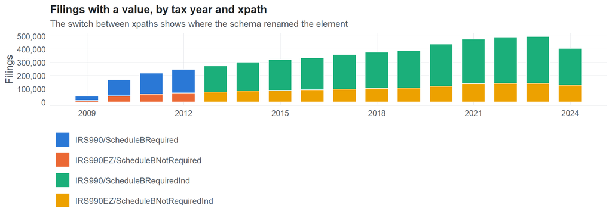

**Table view**

Table view: filings by tax year and series

| Tax year | IRS990/ScheduleBRequired | IRS990EZ/ScheduleBNotRequired | IRS990/ScheduleBRequiredInd | IRS990EZ/ScheduleBNotRequiredInd |
| --- | --- | --- | --- | --- |
| 2009 | 33,311 | 11,146 | 0 | 0 |
| 2010 | 123,025 | 45,877 | 0 | 0 |
| 2011 | 159,504 | 59,389 | 0 | 0 |
| 2012 | 179,688 | 67,669 | 0 | 0 |
| 2013 | 0 | 0 | 198,855 | 74,887 |
| 2014 | 0 | 0 | 218,619 | 83,233 |
| 2015 | 0 | 0 | 233,519 | 88,678 |
| 2016 | 0 | 0 | 243,903 | 92,075 |
| 2017 | 0 | 0 | 261,612 | 97,592 |
| 2018 | 0 | 0 | 271,442 | 104,325 |
| 2019 | 0 | 0 | 283,694 | 106,582 |
| 2020 | 0 | 0 | 320,343 | 118,557 |
| 2021 | 0 | 0 | 336,488 | 139,644 |
| 2022 | 0 | 0 | 349,062 | 141,244 |
| 2023 | 0 | 0 | 354,774 | 141,068 |
| 2024 | 0 | 0 | 277,302 | 127,820 |

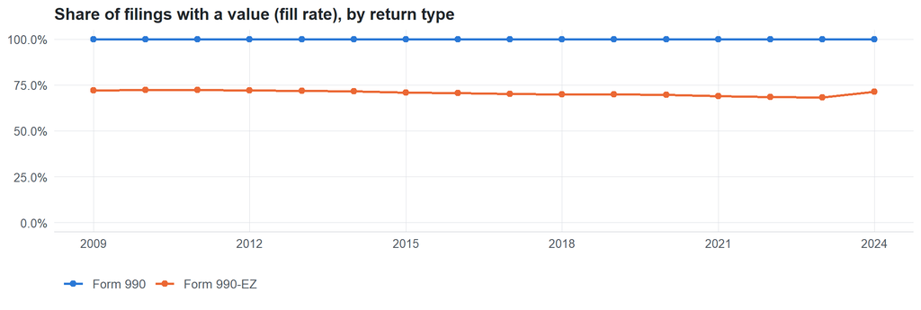

**Table view**

Table view: fill rate

| Tax year | Return type | Filings | All filings | Fill rate |
| --- | --- | --- | --- | --- |
| 2009 | Form 990 | 33,311 | 33,311 | 100.00% |
| 2009 | Form 990-EZ | 11,146 | 15,470 | 72.05% |
| 2010 | Form 990 | 123,025 | 123,025 | 100.00% |
| 2010 | Form 990-EZ | 45,877 | 63,326 | 72.45% |
| 2011 | Form 990 | 159,504 | 159,504 | 100.00% |
| 2011 | Form 990-EZ | 59,389 | 82,048 | 72.38% |
| 2012 | Form 990 | 179,688 | 179,688 | 100.00% |
| 2012 | Form 990-EZ | 67,669 | 93,750 | 72.18% |
| 2013 | Form 990 | 198,855 | 198,855 | 100.00% |
| 2013 | Form 990-EZ | 74,887 | 104,375 | 71.75% |
| 2014 | Form 990 | 218,619 | 218,619 | 100.00% |
| 2014 | Form 990-EZ | 83,233 | 116,417 | 71.50% |
| 2015 | Form 990 | 233,519 | 233,519 | 100.00% |
| 2015 | Form 990-EZ | 88,678 | 124,894 | 71.00% |
| 2016 | Form 990 | 243,903 | 243,903 | 100.00% |
| 2016 | Form 990-EZ | 92,075 | 130,484 | 70.56% |
| 2017 | Form 990 | 261,612 | 261,612 | 100.00% |
| 2017 | Form 990-EZ | 97,591 | 139,144 | 70.14% |
| 2018 | Form 990 | 271,442 | 271,442 | 100.00% |
| 2018 | Form 990-EZ | 104,325 | 149,384 | 69.84% |
| 2019 | Form 990 | 283,694 | 283,694 | 100.00% |
| 2019 | Form 990-EZ | 106,582 | 152,622 | 69.83% |
| 2020 | Form 990 | 320,342 | 320,342 | 100.00% |
| 2020 | Form 990-EZ | 118,557 | 169,864 | 69.80% |
| 2021 | Form 990 | 336,480 | 336,480 | 100.00% |
| 2021 | Form 990-EZ | 139,643 | 202,724 | 68.88% |
| 2022 | Form 990 | 349,055 | 349,055 | 100.00% |
| 2022 | Form 990-EZ | 141,241 | 206,130 | 68.52% |
| 2023 | Form 990 | 354,768 | 354,768 | 100.00% |
| 2023 | Form 990-EZ | 141,067 | 206,379 | 68.35% |
| 2024 | Form 990 | 277,298 | 277,298 | 100.00% |
| 2024 | Form 990-EZ | 127,820 | 178,867 | 71.46% |

## Values

| Result | Check | Detail |
| --- | --- | --- |
| ✓ pass | Values are checkbox codes | 100.0% of values are X / true / false / 1 / 0 |
| ⓘ info | Meaning of a blank | 36% of values are explicit false/0, so a missing value is not the same as unchecked |
| ⚠ fail | Element names agree in polarity | negated: ScheduleBNotRequired, ScheduleBNotRequiredInd \| not negated: ScheduleBRequired, ScheduleBRequiredInd |

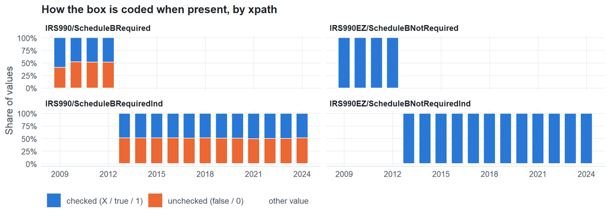

**Table view**

Table view: value coding by tax year

| Series | Tax year | Code | Filings | Share |
| --- | --- | --- | --- | --- |
| IRS990/ScheduleBRequired | 2009 | checked (X / true / 1) | 19,538 | 58.7% |
| IRS990/ScheduleBRequired | 2009 | unchecked (false / 0) | 13,773 | 41.3% |
| IRS990/ScheduleBRequired | 2010 | checked (X / true / 1) | 59,181 | 48.1% |
| IRS990/ScheduleBRequired | 2010 | unchecked (false / 0) | 63,844 | 51.9% |
| IRS990/ScheduleBRequired | 2011 | checked (X / true / 1) | 77,144 | 48.4% |
| IRS990/ScheduleBRequired | 2011 | unchecked (false / 0) | 82,360 | 51.6% |
| IRS990/ScheduleBRequired | 2012 | checked (X / true / 1) | 87,223 | 48.5% |
| IRS990/ScheduleBRequired | 2012 | unchecked (false / 0) | 92,465 | 51.5% |
| IRS990EZ/ScheduleBNotRequired | 2009 | checked (X / true / 1) | 11,146 | 100.0% |
| IRS990EZ/ScheduleBNotRequired | 2010 | checked (X / true / 1) | 45,877 | 100.0% |
| IRS990EZ/ScheduleBNotRequired | 2011 | checked (X / true / 1) | 59,389 | 100.0% |
| IRS990EZ/ScheduleBNotRequired | 2012 | checked (X / true / 1) | 67,669 | 100.0% |
| IRS990/ScheduleBRequiredInd | 2013 | checked (X / true / 1) | 96,775 | 48.7% |
| IRS990/ScheduleBRequiredInd | 2013 | unchecked (false / 0) | 102,080 | 51.3% |
| IRS990/ScheduleBRequiredInd | 2014 | checked (X / true / 1) | 106,212 | 48.6% |
| IRS990/ScheduleBRequiredInd | 2014 | unchecked (false / 0) | 112,407 | 51.4% |
| IRS990/ScheduleBRequiredInd | 2015 | checked (X / true / 1) | 113,686 | 48.7% |
| IRS990/ScheduleBRequiredInd | 2015 | unchecked (false / 0) | 119,833 | 51.3% |
| IRS990/ScheduleBRequiredInd | 2016 | checked (X / true / 1) | 119,070 | 48.8% |
| IRS990/ScheduleBRequiredInd | 2016 | unchecked (false / 0) | 124,833 | 51.2% |
| IRS990/ScheduleBRequiredInd | 2017 | checked (X / true / 1) | 128,758 | 49.2% |
| IRS990/ScheduleBRequiredInd | 2017 | unchecked (false / 0) | 132,854 | 50.8% |
| IRS990/ScheduleBRequiredInd | 2018 | checked (X / true / 1) | 132,400 | 48.8% |
| IRS990/ScheduleBRequiredInd | 2018 | unchecked (false / 0) | 139,042 | 51.2% |
| IRS990/ScheduleBRequiredInd | 2019 | checked (X / true / 1) | 139,402 | 49.1% |
| IRS990/ScheduleBRequiredInd | 2019 | unchecked (false / 0) | 144,292 | 50.9% |
| IRS990/ScheduleBRequiredInd | 2020 | checked (X / true / 1) | 158,794 | 49.6% |
| IRS990/ScheduleBRequiredInd | 2020 | unchecked (false / 0) | 161,549 | 50.4% |
| IRS990/ScheduleBRequiredInd | 2021 | checked (X / true / 1) | 169,603 | 50.4% |
| IRS990/ScheduleBRequiredInd | 2021 | unchecked (false / 0) | 166,885 | 49.6% |
| IRS990/ScheduleBRequiredInd | 2022 | checked (X / true / 1) | 174,248 | 49.9% |
| IRS990/ScheduleBRequiredInd | 2022 | unchecked (false / 0) | 174,814 | 50.1% |
| IRS990/ScheduleBRequiredInd | 2023 | checked (X / true / 1) | 177,183 | 49.9% |
| IRS990/ScheduleBRequiredInd | 2023 | unchecked (false / 0) | 177,591 | 50.1% |
| IRS990/ScheduleBRequiredInd | 2024 | checked (X / true / 1) | 135,419 | 48.8% |
| IRS990/ScheduleBRequiredInd | 2024 | unchecked (false / 0) | 141,883 | 51.2% |
| IRS990EZ/ScheduleBNotRequiredInd | 2013 | checked (X / true / 1) | 74,887 | 100.0% |
| IRS990EZ/ScheduleBNotRequiredInd | 2014 | checked (X / true / 1) | 83,233 | 100.0% |
| IRS990EZ/ScheduleBNotRequiredInd | 2015 | checked (X / true / 1) | 88,678 | 100.0% |
| IRS990EZ/ScheduleBNotRequiredInd | 2016 | checked (X / true / 1) | 92,075 | 100.0% |
| IRS990EZ/ScheduleBNotRequiredInd | 2017 | checked (X / true / 1) | 97,592 | 100.0% |
| IRS990EZ/ScheduleBNotRequiredInd | 2018 | checked (X / true / 1) | 104,325 | 100.0% |
| IRS990EZ/ScheduleBNotRequiredInd | 2019 | checked (X / true / 1) | 106,582 | 100.0% |
| IRS990EZ/ScheduleBNotRequiredInd | 2020 | checked (X / true / 1) | 118,557 | 100.0% |
| IRS990EZ/ScheduleBNotRequiredInd | 2021 | checked (X / true / 1) | 139,644 | 100.0% |
| IRS990EZ/ScheduleBNotRequiredInd | 2022 | checked (X / true / 1) | 141,244 | 100.0% |
| IRS990EZ/ScheduleBNotRequiredInd | 2023 | checked (X / true / 1) | 141,068 | 100.0% |
| IRS990EZ/ScheduleBNotRequiredInd | 2024 | checked (X / true / 1) | 127,820 | 100.0% |

Raw values by xpath (all years)

| Series | Value | Filings |
| --- | --- | --- |
| IRS990/ScheduleBRequired | false | 160,138 |
| IRS990/ScheduleBRequired | 1 | 129,909 |
| IRS990/ScheduleBRequired | true | 113,177 |
| IRS990/ScheduleBRequired | 0 | 92,304 |
| IRS990EZ/ScheduleBNotRequired | X | 184,081 |
| IRS990/ScheduleBRequiredInd | false | 1,179,908 |
| IRS990/ScheduleBRequiredInd | true | 846,796 |
| IRS990/ScheduleBRequiredInd | 1 | 804,754 |
| IRS990/ScheduleBRequiredInd | 0 | 518,155 |
| IRS990EZ/ScheduleBNotRequiredInd | X | 1,315,705 |

## Examples

| Tax year | Return | Xpath | Organization | Value | Source |
| --- | --- | --- | --- | --- | --- |
| 2024 | 990 | IRS990/ScheduleBRequiredInd | IAAI FOUNDATION INC | false | [XML](https://gt990datalake-rawdata.s3.amazonaws.com/EfileData/XmlFiles/202523089349301317_public.xml) |
| 2024 | 990EZ | IRS990EZ/ScheduleBNotRequiredInd | FOUNDATION FOR HEALTH ENVIRONMENTS RESEA | X | [XML](https://gt990datalake-rawdata.s3.amazonaws.com/EfileData/XmlFiles/202523219349201597_public.xml) |
| 2023 | 990 | IRS990/ScheduleBRequiredInd | ZEPF CENTER | 1 | [XML](https://gt990datalake-rawdata.s3.amazonaws.com/EfileData/XmlFiles/202423399349300887_public.xml) |
| 2023 | 990EZ | IRS990EZ/ScheduleBNotRequiredInd | GALBRAITH GRAVITY JUNIOR RACING | X | [XML](https://gt990datalake-rawdata.s3.amazonaws.com/EfileData/XmlFiles/202422849349200002_public.xml) |
| 2022 | 990 | IRS990/ScheduleBRequiredInd | MERRILL COMMUNITY HOMELESS CENTER INC | true | [XML](https://gt990datalake-rawdata.s3.amazonaws.com/EfileData/XmlFiles/202331589349300003_public.xml) |
| 2022 | 990EZ | IRS990EZ/ScheduleBNotRequiredInd | Mayflower Choral Society | X | [XML](https://gt990datalake-rawdata.s3.amazonaws.com/EfileData/XmlFiles/202440859349201859_public.xml) |
| 2021 | 990 | IRS990/ScheduleBRequiredInd | AFRICA NETWORK FOR ANIMAL WELFARE- USA | true | [XML](https://gt990datalake-rawdata.s3.amazonaws.com/EfileData/XmlFiles/202222209349300402_public.xml) |
| 2021 | 990EZ | IRS990EZ/ScheduleBNotRequiredInd | BLAINE 1 INC | X | [XML](https://gt990datalake-rawdata.s3.amazonaws.com/EfileData/XmlFiles/202201369349200340_public.xml) |
| 2020 | 990 | IRS990/ScheduleBRequiredInd | CHARLOTTE HARBOR WATER ASSOCIATION INC | 0 | [XML](https://gt990datalake-rawdata.s3.amazonaws.com/EfileData/XmlFiles/202132739349301608_public.xml) |
| 2020 | 990EZ | IRS990EZ/ScheduleBNotRequiredInd | Kiwanis International | X | [XML](https://gt990datalake-rawdata.s3.amazonaws.com/EfileData/XmlFiles/202220349349200542_public.xml) |
| 2019 | 990 | IRS990/ScheduleBRequiredInd | Chauffeurs Teamsters & Helpers Local 878 | false | [XML](https://gt990datalake-rawdata.s3.amazonaws.com/EfileData/XmlFiles/202043219349315409_public.xml) |
| 2019 | 990EZ | IRS990EZ/ScheduleBNotRequiredInd | CALVARY CHURCH ASSEMBLY OF GOD | X | [XML](https://gt990datalake-rawdata.s3.amazonaws.com/EfileData/XmlFiles/202021979349204507_public.xml) |

## Reviewer checklist

- The definition matches the form line and instructions for every xpath’s schema years.
- Every xpath pooled here measures the same thing on the 990 and 990-EZ (close enough for analysis).
- The coverage chart has no unexplained gaps or jumps between tax years.
- Each open flag is fixed, or accepted with a note in validation_log.csv.
- The box means the same thing (and the same polarity) under every xpath: ‘required’ is never pooled with ‘not required’.
- Absent means unchecked for this line, or the question was skipped; the data dictionary says which.
- Yes/No questions coded as two separate boxes are mapped to one variable only when that is intended.

Record the review as a row in `inst/extdata/src/validation_log.csv` (variable_name, reviewer, date, status, note). Evidence built 2026-09-23 17:09:04 MST from the ef2 DuckDB builds (tax years 2009–2024).